# Ch9: Support Vector Machines

Philip Lin

2015.1.21

# Outline

We discuss two-class classifier only

- Linear classifier in separable case
  - Separating Hyperplanes
  - Optimal Separating Hyperplanes
- Linear classifier in nonseparable case
  - Support Vector Classifiers
- Nonlinear classifier in nonseparable case
  - Support Vector Machine
  - Kernel trick and basis expansion
  - In the view of regularization

# An motivative example

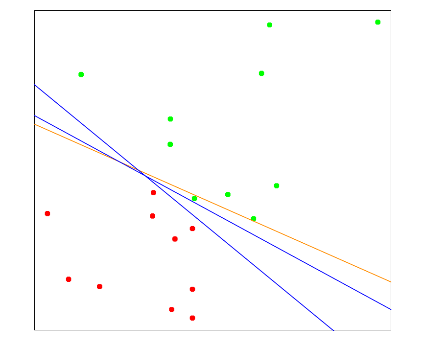

- Intuitively, we can construct a linear decision boundary to **perfectly** separate green and red points easily. However, there are infinitly many hyperplanes can do it.
- The distance of an observation from the hyperplane can be seen as a measure of our confidence that the observation was correctly classified. Why ?

# Separating Hyperplanes

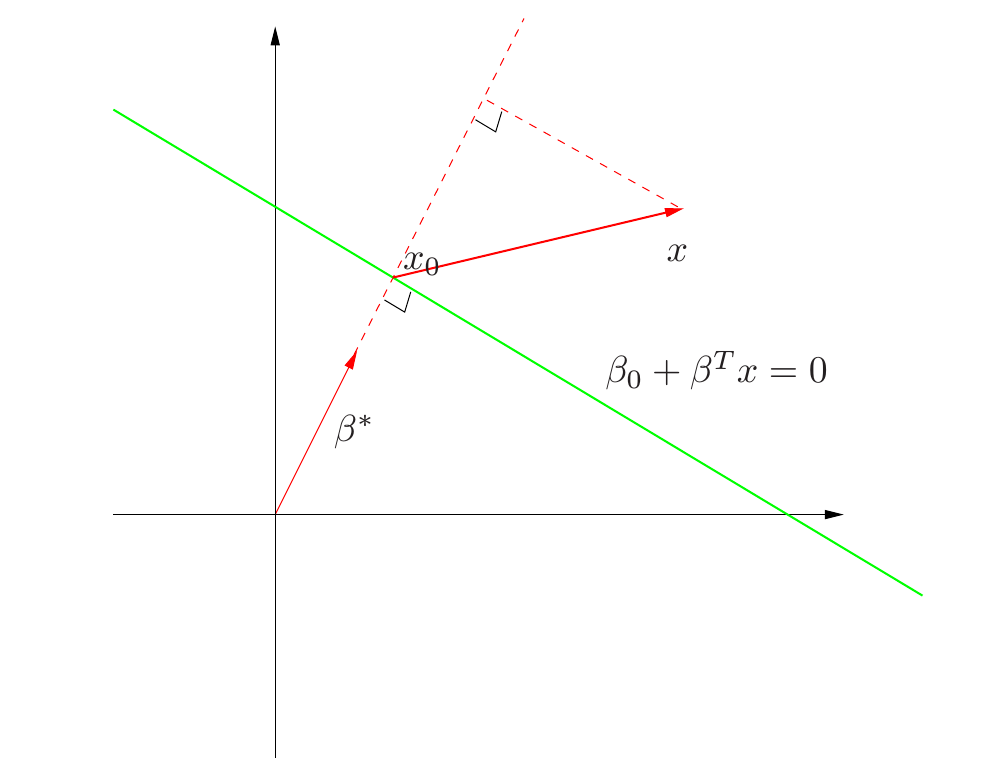

Consider $y=\{-1,1\}$, the line is given by $\{x:\hat{\beta}_0 + \hat{\beta}x =0\}$

- **perceptron**: compute a linear combination of the imput feature and return the sign.
  1. any two points $x_1, x_2$ lying in $L:f(x)=\beta_0+\beta^Tx=0$ (green line) $f(x_1)-f(x_2)=\beta^T(x_1-x_2)=0$ we can find a norm vector that is orthogonal to surface $L$ $\beta^*=\frac{\beta}{\|\beta\|}$
  2. for any point $x_0$ in $L$ $f(x_0)=\beta_0+\beta^Tx_0=0~, ~~\beta^T x_0=-\beta_0$
  3. The signed distance of any point $x$ to $L$ is given by projecting $(x-x_0)$ to $\beta^*$ $\begin{align*} \beta^{*T}(x-x_0) =& \frac{\beta^T}{\|\beta\|}(x-x_0) = \frac{1}{\|\beta\|}(\beta^Tx-\beta^Tx_0)\\ =&\frac{1}{\|f'(x)\|}(\beta^Tx + \beta_0) \\ =& \frac{1}{\|f'(x)\|}f(x) \end{align*}$

# Rosenblatt’s perceptron learning algorithm

- If $y_i=1$ is misclassified, then $x_i^T\beta+\beta_0<0$, and the opposite for a misclassified response with $y_i=-1$
- The goal is to minimize $D(\beta,\beta_0)=-\sum_{i\in\mathcal{M}}y_i(x_i^T\beta+\beta_0)$ where $\mathcal{M}$ indexes the set of misclassified points
- $D(\beta,\beta_0)$ is nonnegative and proportional to the distance of misclassified points to the decision boundary defined by $\beta^Tx+\beta_0=0$
- The gradient is given by $\frac{\partial D(\beta,\beta_0)}{\partial\beta}=-\sum_{i\in\mathcal{M}}y_ix_i, ~~ \frac{\partial D(\beta,\beta_0)}{\partial\beta_0}=-\sum_{i\in\mathcal{M}}y_i$
- The algorithm in fact uses stochastic gradient descent to minimize this piecewise linear criterion. ${\beta\choose\beta_0} \longleftarrow {\beta\choose\beta_0} + \rho {y_ix_i\choose y_i}$
- Drawbacks
  - When data are separable, there are many solutions, and which one is found depends on the starting values.
  - Uneasy to converge.
  - When data are not separable, the algorithm will not converge.

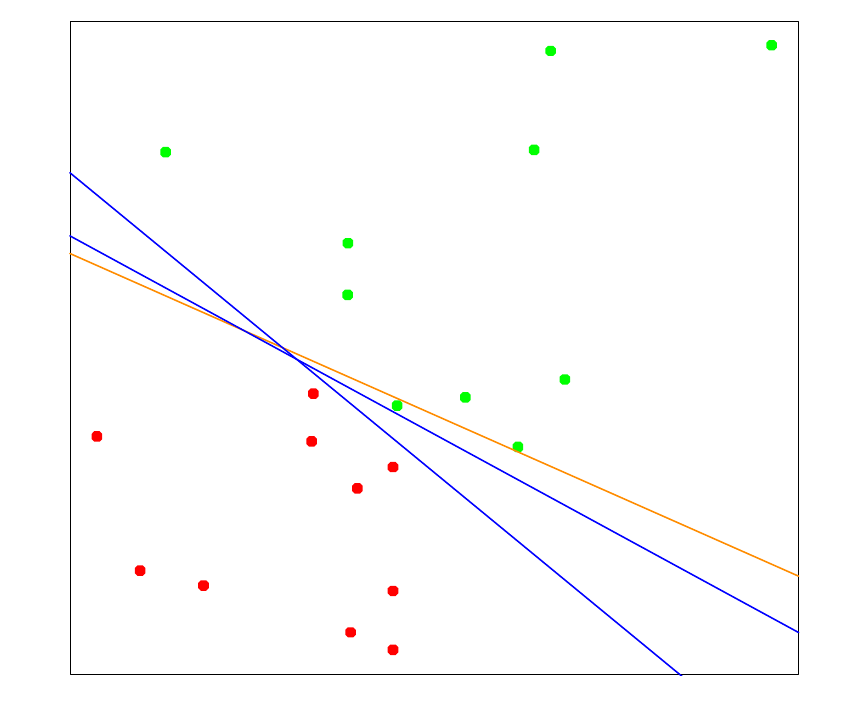

# Optimal Separating Hyperplanes

- Separate the two classes and maximizes the distance to **the closet point** from either classes $\max_{\beta,\beta_0,\|\beta\|=1} M \\ \text{s.t.} ~~~~~ y_i(x_i^T\beta + \beta_0)\geq M, ~~~i=1,\dots,N$
- Constrant $\|\beta\|=1$ is made to ensure the meaning of $y_i(x_i^T\beta + \beta_0)$: the distance of $x_i$ to the decision boundary.
- The set of conditions ensure that all the points are at least a signed distance $M$ from the decision boundary defined by $\beta$ and $\beta_0$.
- This approach not only provides a unique solution to the separating hyperplane problem, but leads to better classification performance on test data.

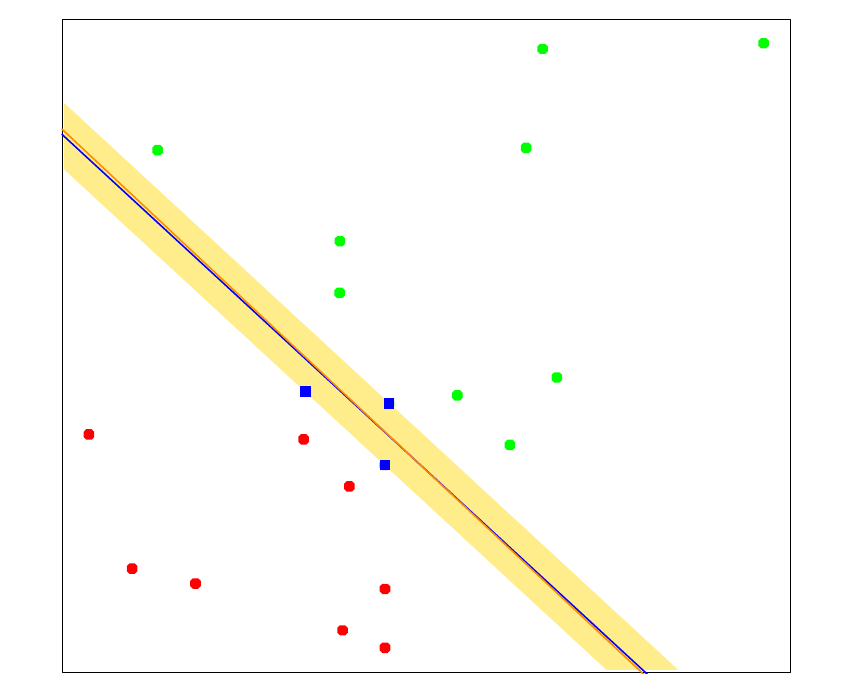

# Optimal Separating Hyperplanes (Computation details)

- To get rid of $\|\beta\|=1$ constraint $\max_{\beta,\beta_0} M ~~ \text{s.t.} ~~ \frac{1}{\|\beta\|}y_i(x_i^T\beta+\beta_0)\geq M$ or $\max_{\beta,\beta_0} M ~~ \text{s.t.} ~~ y_i(x_i^T\beta+\beta_0)\geq M\|\beta\|$ Since for any $\beta,\beta_0$ satisfying these inequalities, any positively scaled multiples satisfies them too. Set $\|\beta\|=\frac{1}{M}$ $\max_{\beta,\beta_0} \frac{1}{\|\beta\|} ~~ \text{s.t.} ~~ y_i(x_i^T\beta+\beta_0)\geq 1, ~~~ i=1,\dots,N$ equivalently $\min_{\beta,\beta_0} \frac{1}{2}\|\beta\|^2 ~~ \text{s.t.} ~~ y_i(x_i^T\beta+\beta_0)\geq 1, ~~~ i=1,\dots,N$
- Lagrange primal function: $L_p=\frac{1}{2}\|\beta\|^2 - \sum_{i=1}^N\alpha_i[y_i(x_i^T\beta+\beta_0)-1]$ Setting first derivative to zero $\begin{align*} \beta =& \sum_{i=1}^N\alpha_iy_ix_i \\ 0 =& \sum_{i=1}^N\alpha_i y_i \end{align*}$ Plug them back to $L_p$, we obtain the Wolfe dual $L_D=\sum_{i=1}^N\alpha_i-\frac{1}{2}\sum_{i=1}^N\sum_{k=1}^N\alpha_i\alpha_k y_iy_kx_i^Tx_k ~~~~~ \text{s.t.} ~~ \alpha_i\geq 0$
- By checking KKT condition, we have $\alpha_i[y_i(x_i^T\beta + \beta_0)-1]=0 ~~~ \forall ~ i$ we can see
  - if $\alpha_i>0$, $y_i(x_i^T\beta+\beta_0)=1$, then $x_i$ is on the boundary of the slab.
  - if $y_i(x_i^T\beta+\beta_0)>1$, $x_i$ is not on the boundary of the slab, and $\alpha_i=0$, which contributes nothing to $L_D$.
  - From $\beta = \sum_{i=1}^N\alpha_iy_ix_i$, $\beta$ is defined in terms of a linear combination of the support points $x_i$ — those points defined to be on the boundary of the slab via $\alpha_i>0$
- The constraints define a margin around the linear decision boundary of thickness $1/\|\beta\|$. Hence we choose $\beta$ and $\beta_0$ to maximize its thickness.

# Support Vector Classifier

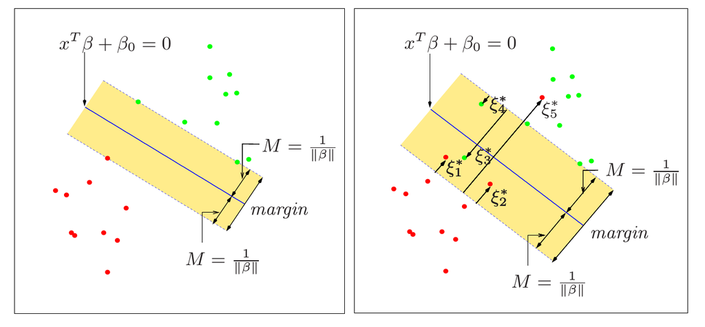

- When classes overlap in feature space (nonseparable), one way to deal with the overlap is to still maximize $M$, but allow for some points to be on the wrong side of the margin.
- Along with optimal separating hyperplane $\max_{\beta,\beta_0,\|\beta\|=1} M \\ \text{s.t.} ~~~~~ y_i(x_i^T\beta + \beta_0)\geq M, ~~~i=1,\dots,N$ define the slack variables $\xi=(\xi_1,\dots,\xi_N)$, there are two ways to modify the constraint in optimal separating hyperplane

$y_i(x_i^T\beta+\beta_0)\geq M-\xi_i$ or $y_i(x_i^T\beta+\beta_0)\geq M(1-\xi_i)$ $\forall~i, \xi_i\geq 0, \sum_{i=1}^N\xi_i\leq\text{constant}$

- Remarks
  - In the first inequality, $\xi_i$ means the distance from the margin for which $i$th observation is on the wrong side.
  - In the second inequality, $\xi_i^*=M\xi_i$ means the distance from the margin for which $i$th observation is on the wrong side.
  - Although the first inequality is more intuitive, it leads to nonconvex optimization. Thus we prefer the second inequality, which leads to convex optimization. We prefer the second inequality.
  - In the second inequality, $\xi_i=0$ if $i$th observation is on the correct side and out of margin. Misclassification occurs if $\xi_i>1$
  - By bounding $\sum_{i=1}^N\xi_i$, we bound the total proportional amount by which predictions fall on the wrong side of their margin.
  - Points well inside their class boundary do not play a big role in shaping the boundary.

# Support Vector Classifier (computation details)

- Drop the norm constraint on $\beta$ and denote $M=\frac{1}{\|\beta\|}$ $\begin{align*} \min\|\beta\| ~~\text{s.t.} ~~~~~ &y_i(x_i^T\beta+\beta_0)\geq 1-\xi_i, \forall ~ i \\ &\xi_i\geq 0, \sum\xi_i\leq \text{Constant} \end{align*}$ equivalently $\min_{\beta,\beta_0}\frac{1}{2}\|\beta\|^2 + C\sum_{i=1}^N\xi_i ~~\text{s.t.} ~~~~~ \xi_i\geq 0, ~~~ y_i(x_i^T\beta+\beta_0)\geq 1-\xi_i, \forall i$
- Lagrange primal $L_p=\frac{1}{2}\|\beta\|^2 + C\sum_{i=1}^N\xi_i - \sum_{i=1}^N\alpha_i[y_i(x_i^T\beta+\beta_0)-(1-\xi_i)] - \sum_{i=1}^N\mu_i\xi_i$ We minimize w.r.t. $\beta,\beta_0,\xi_i$ with multiplier $C, \alpha_i, \mu_i$
- Set first derivative to zero, for $\alpha_i,\mu_i,\xi_i\geq 0$ $\begin{align*} \beta =& \sum_{i=1}^N\alpha_iy_ix_i \\ 0 =& \sum_{i=1}^N\alpha_iy_i \\ \alpha_i =& C-\mu_i ~~~,\forall i \end{align*}$ plug them back to $L_p$, we obtain the Wolfe dual $L_D=\sum_{i=1}^N\alpha_i - \frac{1}{2}\sum_{i=1}^N\sum_{i'=1}^N\alpha_i\alpha_{i'}y_iy_{i'}x_i^Tx_{i'}$
- By checking KKT condition, for $i=1,\dots,N$ $\begin{align*} \alpha_i[y_i(x_i^T\beta+\beta_0)-(1-\xi_i)] =& 0 \\ \mu_i\xi_i=&0 \\ y_i(x_i^T\beta+\beta_0)-(1-\xi_i)\geq& 0 \end{align*}$ we can see
  - the solution for $\beta$ has the form $\hat{\beta}=\sum_{i=1}^N\hat{\alpha}_iy_ix_i$ with nonzero coefficients $\hat{\alpha}_i$ only for those observations $i$ for which the constrant $y_i(x_i^T\beta+\beta)=1-\xi_i$. These observations are called the **support vectors**.
  - Among these support points, some will lie on the edge of the margin ($\hat{\xi}_i=0$), they correspond to $0<\hat{\alpha}_i<C$. By the equation $\alpha_i[y_i(x_i^T\beta+\beta_0)-(1-\xi_i)] = 0$ we can see that any of these margin points ($0<\hat{\alpha}_i,\hat{\xi}_i=0$) can be used to solve for $\beta_0$.

# Support Vector Machine

- What if the relationship between feature and response is nonlinear, $y=f(x)$ ?
- Define basis functions $h_m(x),m=1,\dots,M$
  1. **basis expansion**: $f(x)=h(x)^T\beta + \beta_0$ $\min_{\beta,\beta_0}\frac{1}{2}\|\beta\|^2 + C\sum_{i=1}^N\xi_i ~~\text{s.t.} ~~~~~ \xi_i\geq 0, ~~~ y_if(x)\geq 1-\xi_i, \forall i$ then all the procedure is same as before…
  2. **Reproducing kernel**: $f(x)=\sum_{i=1}^N\alpha_iy_i<h(x),h(x_i)>+\beta_0$ $L_D=\sum_{i=1}^N\alpha_i - \frac{1}{2}\sum_{i=1}^N\sum_{i'=1}^N\alpha_i\alpha_{i'}y_iy_{i'}<h(x_i),h(x_{i'})>$ then all the procedure is same as before…
- Actually, 1. and 2. are exactly the same [(ref)](http://amstat.tandfonline.com/doi/abs/10.1198/000313006X124541)
- Choice of kernels [(ref)](http://crsouza.blogspot.tw/2010/03/kernel-functions-for-machine-learning.html)

# Support Vector Machine

- How to explain SVM in the view of Reproducing Kernel ?
- *“God created infinity, and man, unable to understand infinity, had to invent finite sets.” — Kronecker*
- Is it possible that the sample comes from another space $F$ (in higher dimension, could be $\infty$) and they can be separated by a simple rule in $F$ than in original space ?

$\begin{align*} \Phi:R^N&\longmapsto F \\ x &\longmapsto \Phi(x) \end{align*}$

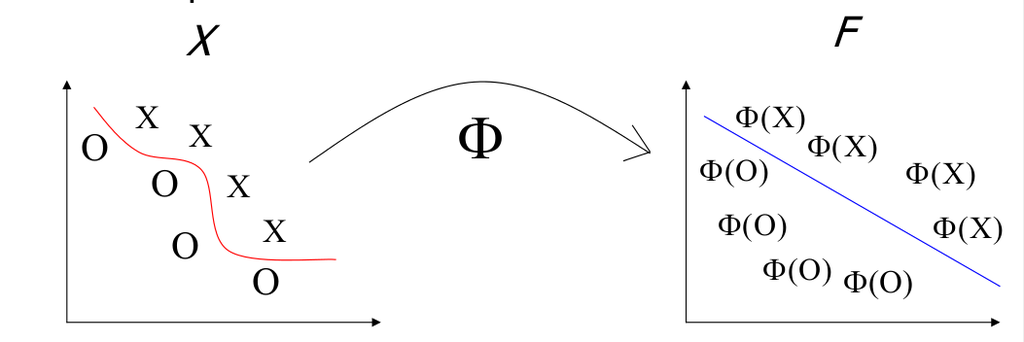

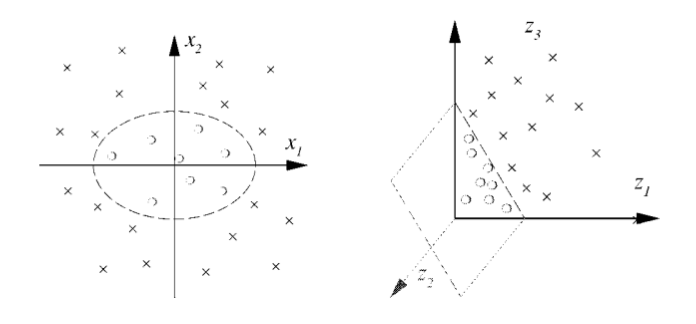

# Support Vector Machine

$\begin{align*} \Phi:R^N&\longmapsto F \\ x &\longmapsto \Phi(x) \end{align*}$

- However, $\Phi$ is unknown. Even $\Phi$ is known, I don’t to handle the data that is located in infinite dimension.
  - An elegent Fact in computer science *“Every (linear) algorithm that only uses scalar products can implicitly be excuted in $F$ by using kernels.”*
  - So far, inner product in infinite dimension is well defined. (keyword: **Reproducing Kernel Hilbert Space**)
- Define kernel function $k(x,y)=(\Phi(x)\cdot\Phi(y))$
- Example

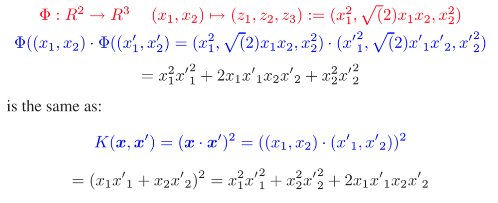

[(ref)](http://www.cs.columbia.edu/~kathy/cs4701/documents/jason_svm_tutorial.pdf)

- Video: [polynomial SVM](https://www.youtube.com/watch?v=3liCbRZPrZA)

# Support Vector Machine: in the view of regularization

With $f(x)=h(x)^T\beta + \beta_0$, consider the optimization problem $\min_{\beta_0,\beta}\sum_{i=1}^N[1-y_if(x_i)]_+ + \frac{\lambda}{2}\|\beta\|^2$

- It can be proved the solution of this regularization problem is same as SVM we discussed in last few pages with $\lambda=\frac{1}{C}$.
- The loss function is **hinge loss**, which assign zero loss for the out-of-margin points.

# What are we going to do ?

$y = f(X) + \epsilon$

- Unsupervised learning
  - Unsupervised Learning (Ch10)
- Supervised learning (Inference purpose)
  - Linear regression (Ch3)
  - Classification (Ch4)
  - Resampling method (Ch5)
  - Linear model selection and regularization (Ch6)
  - Moving beyond linearity (Ch7)
- Supervised learning (Prediction purpose)
  - Tree based method (Ch8)
  - Support Vector Machine (Ch9)